# Yelp Business Analyze

2019/12/17

## Table of Content

- Project Overview
- Data Manipulation
- Maps: Method
- Maps: Examples & Results
- WordClouds: Method
- WordClouds: Examples & Results
- SENTIMENTAL ANALYZE
- Discussions & Limitation
- Shiny & Future Work

## Yelp Project Overview

This is an Yelp Business Analyze. This presentation shares discoveries from conducting research and analysis on Yelp Dataset. For more details on data source see https://www.yelp.com/dataset/download.

This research forcuses on dataset ‘business’ for restaurant informations and dataset ‘review’ for clients’ comment towards these restanrant. Distribution of the yelp business will be showed in three different dimensions: Worldwide, US, States. This research will also show the features of the most popular restaurants through WordClouds.

## Data Manipulation

- The json file of dataset from yelp was read in and expanded columns using ‘stream_in’ from package ‘jsonlite’.
- For state maps, I deleted all state that’s not in r using ‘subset’ function.
- For WordClouds, I did text mining to match the argument pattern, using functions as ‘gsub’, ‘tolower’, ‘strsplit’.

## Maps: Method

- Plot maps using ‘plot_usmap’ and ‘geom_point’
- To be more fair, I delete the state with one or two business when counting the review density and star rate.
- I leave buisness with five or more comments when calculating the overall correlations.

## Maps: Examples & Results

### World Map

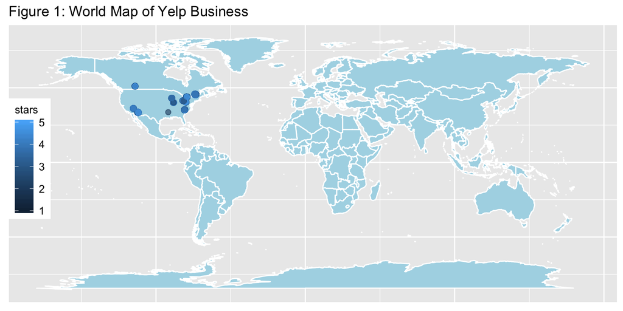

## Maps: Examples & Results

### US Map

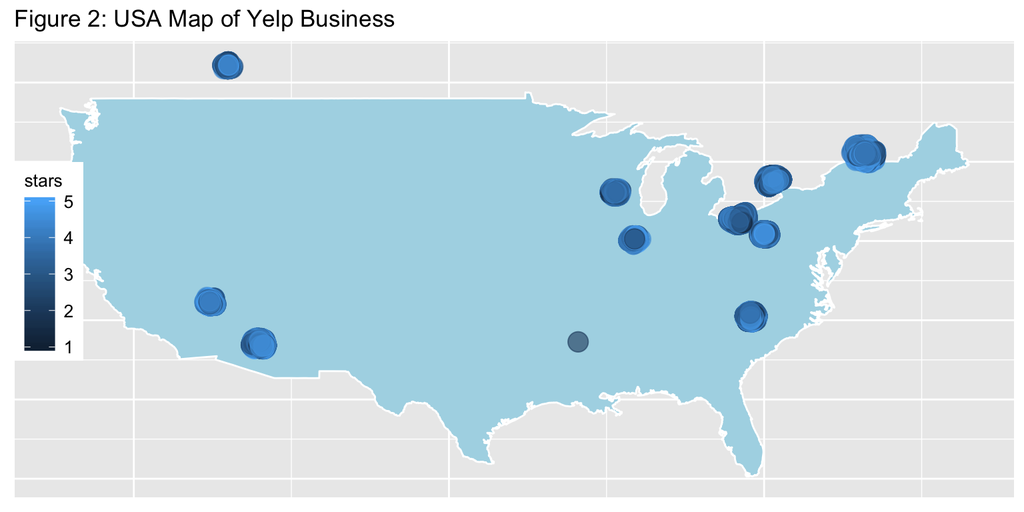

## Maps: Examples & Results

### US Map(Devided by states)

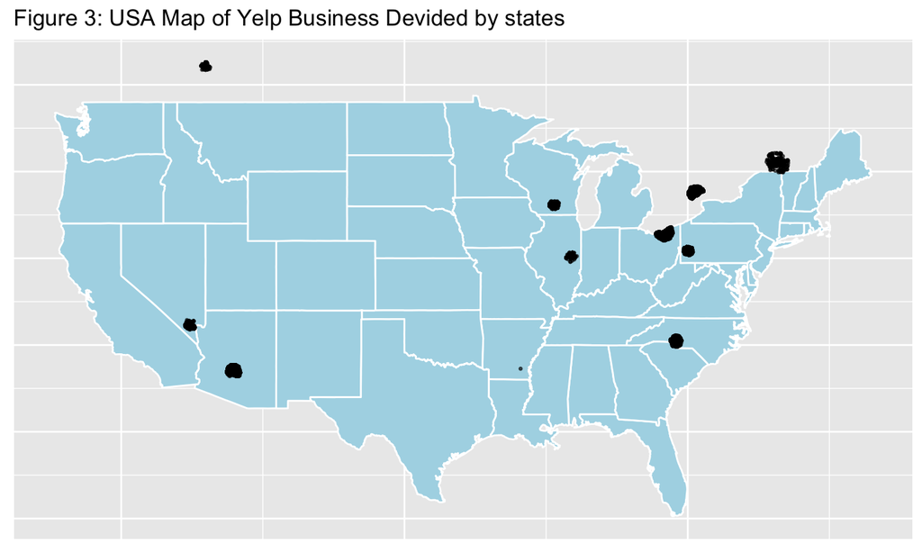

## Maps: Examples & Results

### State Maps

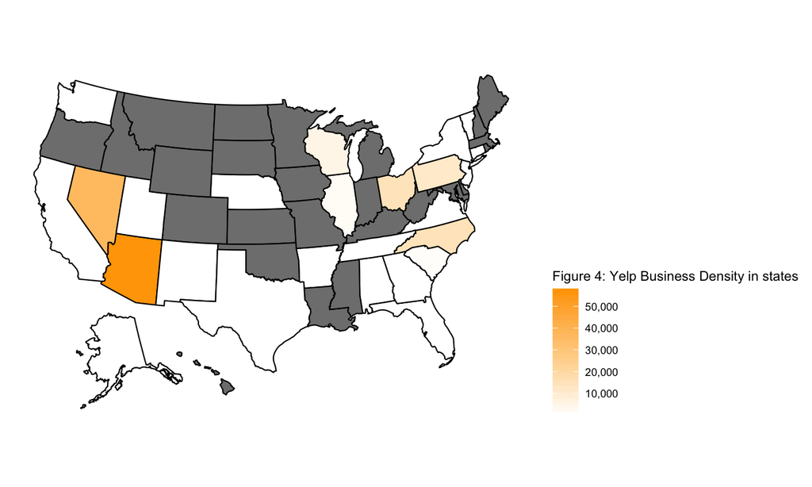

## Maps: Examples & Results

### Review Density

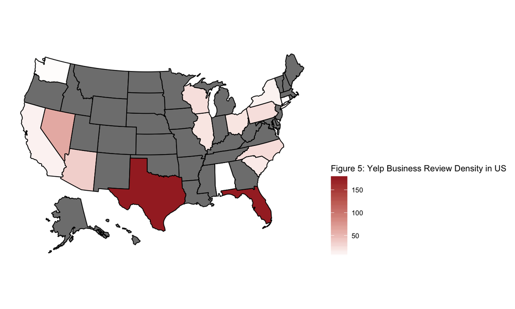

## Maps: Examples & Results

### Star Rate

[figure not shown]

## Maps: Examples & Results

### Aggerate Correlation

```
## # A tibble: 4 x 4
##   n_business.x n_reviews review_density mean_star
##          <dbl>     <dbl>          <dbl>     <dbl>
## 1       1         0.937         -0.0217    0.0204
## 2       0.937     1              0.0617    0.0683
## 3      -0.0217    0.0617         1         0.691
## 4       0.0204    0.0683         0.691     1
```

## Maps: Examples & Results

- The review density do not follow the number of business. People from some state are more tend to leave some comments.
- Correlation between mean_star and rate density is 0.69138460. State with more reviews density has better overall rate.

## WordClouds: Method

- Text Analysis
- Text Tidy: using functions as ‘removeWords’, ‘gsub’, ‘tolower’, ‘strsplit’
- I create a function that break customer reviews in words and analyze word counts that contribute to each sentiment

## WordClouds: Examples & Results

### Take a look at the top 10 frequent words.

```
## text
##            food    good   place   great    time service    just    like     one
##   49129     434     425     414     341     341     329     321     309     308
```

## WordClouds: Examples & Results

### Overall Review Cloud

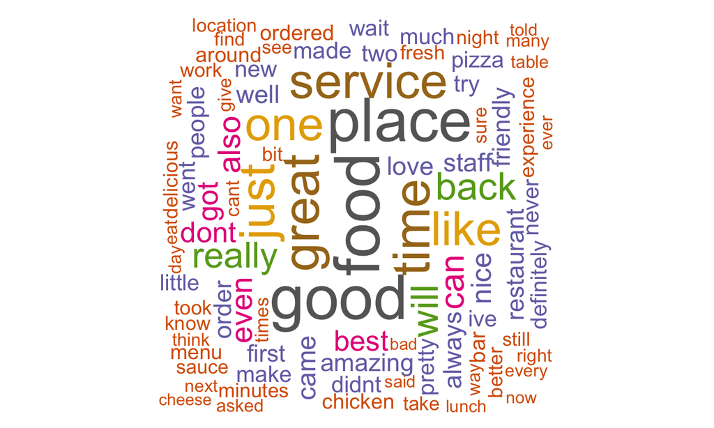

## WordClouds: Examples & Results

### Top1 Popular Restaurant Review Cloud

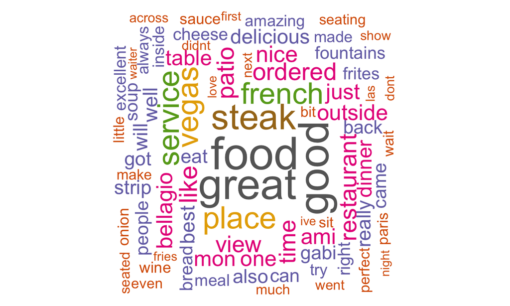

## WordClouds: Examples & Results

### Top2 Popular Restaurant Review Cloud

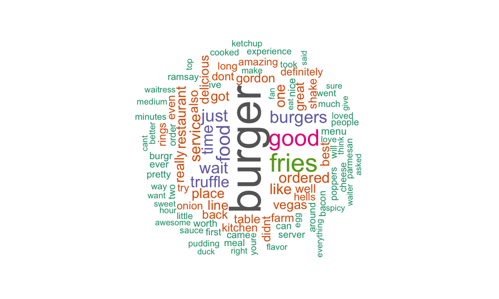

## WordClouds: Examples & Results

### Top3 Popular Restaurant Review Cloud

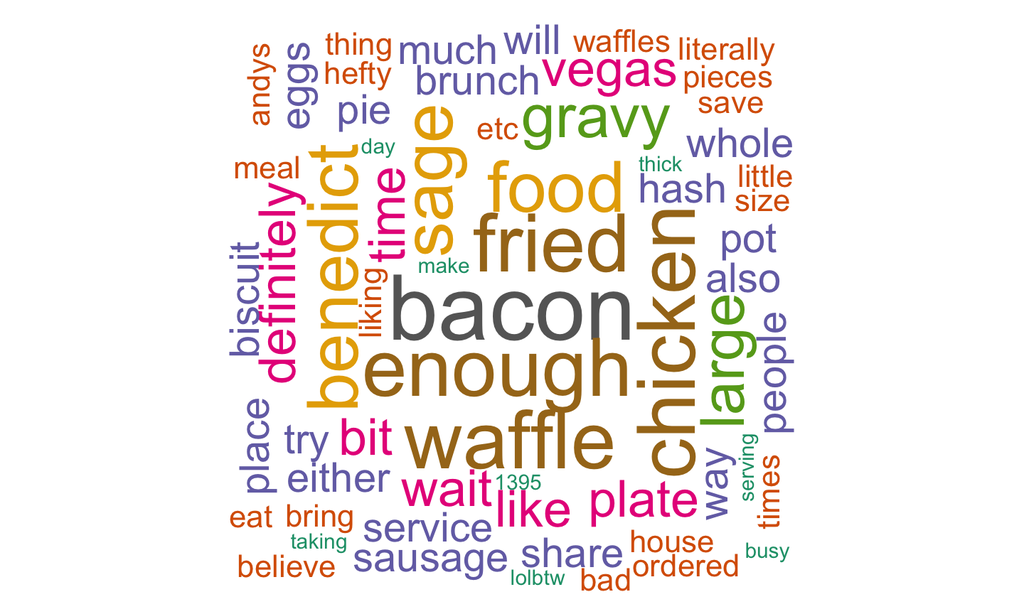

## WordClouds: Examples & Results

### Top4 Popular Restaurant Review Cloud

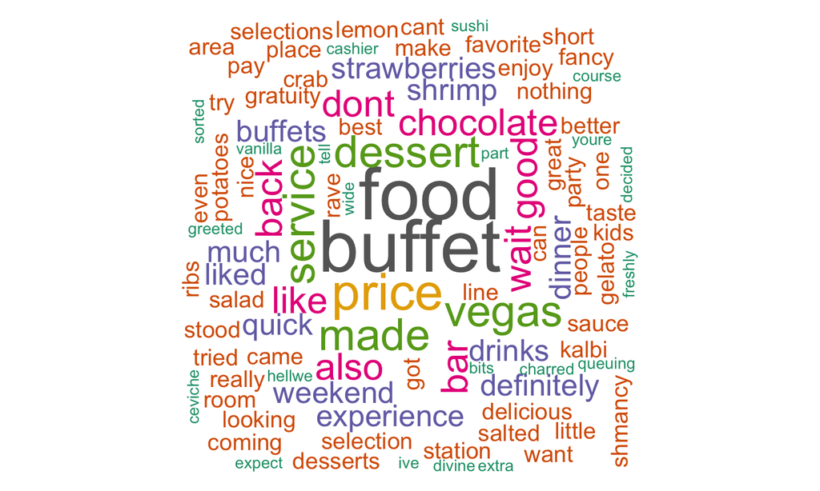

## WordClouds: Examples & Results

### Top5 Popular Restaurant Review Cloud

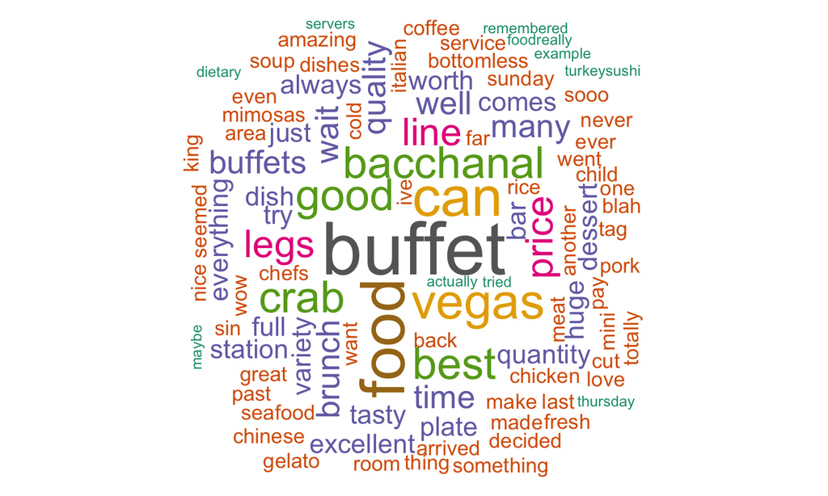

## SENTIMENTAL ANALYZE

### positive

```
## # A tibble: 10 x 3
## # Groups:   sentiment [1]
##    word     sentiment  freq
##    <chr>    <chr>     <dbl>
##  1 amazing  positive    132
##  2 best     positive    163
##  3 friendly positive    132
##  4 good     positive    425
##  5 great    positive    341
##  6 like     positive    309
##  7 love     positive    139
##  8 nice     positive    159
##  9 pretty   positive    118
## 10 well     positive    136
```

## SENTIMENTAL ANALYZE

### negative

```
## # A tibble: 10 x 3
## # Groups:   sentiment [1]
##    word         sentiment  freq
##    <chr>        <chr>     <dbl>
##  1 bad          negative     68
##  2 cheap        negative     27
##  3 cold         negative     31
##  4 disappointed negative     38
##  5 expensive    negative     28
##  6 fried        negative     38
##  7 hard         negative     40
##  8 problem      negative     37
##  9 rude         negative     24
## 10 terrible     negative     24
```

## Discussions & Limitation

- Discussions: The wordcloud is very straight forward that it throws a bunch of common features to users about the restaurant. I enconter some problems
- Limitation: The reviews dataset is 5GB which is too big to readin, I randomly sampled 200000 rows to use. So it may not contains all information and has some bias.

## Shiny & Future Work

- Thanks to https://shiny.rstudio.com/gallery/ for sources about shinyapp.
- I public my shinyapp as an interactive platform to share my analyze and result. It can be found as https://vivianwu.shinyapps.io/final615/
- Due to time concerns, I did not do further analysis, But the next step could be conbining user dataset with the business dataset and review dataset, to get an idea about the different preference of food from clients in different area.